# Análisis Exploratorio de Datos de la Premier League 2021/2022

#### 3.2.2 Análisis Descriptivo de la variable MP (Partidos jugados).

##### A. Cálculo de Estadísticos Descriptivos.

```r
stats_mp <- datos %>%
  filter(!is.na(MP)) %>%
  summarise(
    N_Total = n(),
    Media = mean(MP),
    Mediana = median(MP),
    Desviacion_Tipica = sd(MP),
    RIQ = IQR(MP),
    Asimetria = moments::skewness(MP),
    Curtosis = moments::kurtosis(MP)
  )
print(stats_mp)
```

```
  N_Total    Media Mediana Desviacion_Tipica RIQ Asimetria Curtosis
1     691 15.17366      14          12.95495  27 0.2001996 1.550917
```

##### B. Visualizaciones.

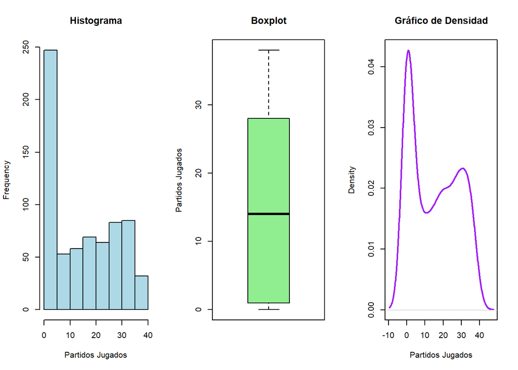

```r
par(mfrow = c(1, 3))  # Configurar para 3 gráficos en una fila
# Histograma
hist(datos$MP,
     main = "Histograma",
     xlab = "Partidos Jugados",
     col = "lightblue",
     border = "black")
# Boxplot
boxplot(datos$MP,
        main = "Boxplot",
        ylab = "Partidos Jugados",
        col = "lightgreen")
# Gráfico de Densidad
plot(density(datos$MP),
     main = "Gráfico de Densidad",
     xlab = "Partidos Jugados",
     col = "purple",
     lwd = 2)
```

```r
par(mfrow = c(1, 1))  # Restaurar configuración
```

#### 3.2.3 Análisis Descriptivo de la variable Min (Minutos jugados).

##### A. Cálculo de Estadísticos Descriptivos.

```r
stats_minutes <- datos %>%
  filter(!is.na(Min)) %>%
  summarise(
    N_Total = n(),
    Media = mean(Min),
    Mediana = median(Min),
    Desviacion_Tipica = sd(Min),
    RIQ = IQR(Min),
    Asimetria = moments::skewness(Min),
    Curtosis = moments::kurtosis(Min)
  )
print(stats_minutes)
```

```
  N_Total    Media Mediana Desviacion_Tipica  RIQ Asimetria Curtosis
1     691 1086.994     853          1060.336 1899 0.5654423 1.997267
```

La variable Min (Minutos jugados) muestra una distribución asimétrica positiva, con una media mayor que la mediana. Esto sugiere que hay algunos jugadores que han jugado un número muy alto de minutos, lo que está influyendo en la media. La desviación típica es alta, indicando una gran variabilidad en los minutos jugados por los jugadores.

##### B. Visualizaciones.

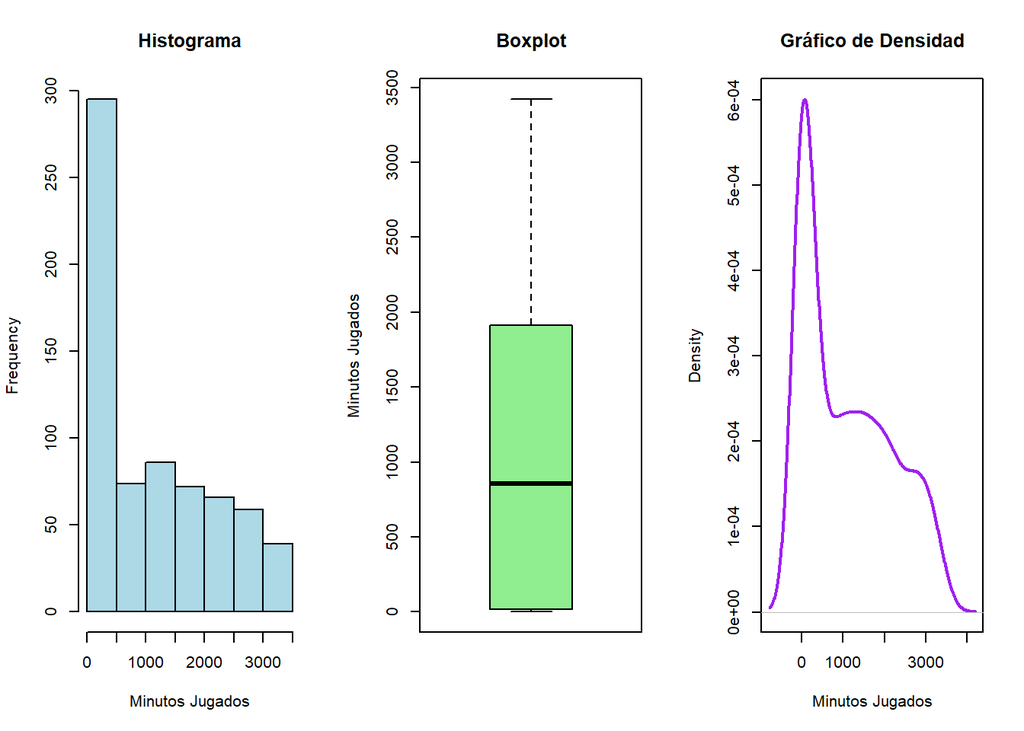

```r
par(mfrow = c(1, 3))  # Configurar para 3 gráficos en una fila
# Histograma
hist(datos$Min,
     main = "Histograma",
     xlab = "Minutos Jugados",
     col = "lightblue",
     border = "black")
# Boxplot
boxplot(datos$Min,
        main = "Boxplot",
        ylab = "Minutos Jugados",
        col = "lightgreen")
# Gráfico de Densidad
plot(density(datos$Min),
     main = "Gráfico de Densidad",
     xlab = "Minutos Jugados",
     col = "purple",
     lwd = 2)
```

```r
par(mfrow = c(1, 1))  # Restaurar configuración
```

#### 3.2.4 Análisis Descriptivo de la variable Gls (Goles anotados).

##### A. Cálculo de Estadísticos Descriptivos.

```r
stats_goals <- datos %>%
  filter(!is.na(Gls)) %>%
  summarise(
    N_Total = n(),
    Media = mean(Gls),
    Mediana = median(Gls),
    Desviacion_Tipica = sd(Gls),
    RIQ = IQR(Gls),
    Asimetria = moments::skewness(Gls),
    Curtosis = moments::kurtosis(Gls)
  )

print(stats_goals)
```

```
  N_Total    Media Mediana Desviacion_Tipica RIQ Asimetria Curtosis
1     691 1.500724       0          2.996314   2  3.241737 16.26979
```

A simples vista, la variable Gls (Goles anotados) presenta una distribución asimétrica positiva, con una media mayor que la mediana, lo que indica que hay algunos jugadores con un número muy alto de goles que están influyendo en la media. La desviación típica es relativamente alta, lo que sugiere una gran variabilidad en el número de goles anotados por los jugadores.

###### B. Visualizaciones.

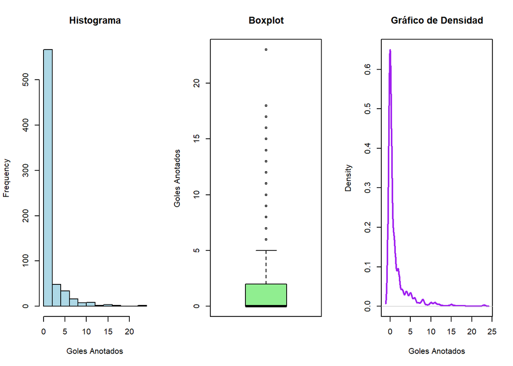

```r
par(mfrow = c(1, 3))  # Configurar para 3 gráficos en una fila
# Histograma
hist(datos$Gls,
     main = "Histograma",
     xlab = "Goles Anotados",
     col = "lightblue",
     border = "black")
# Boxplot
boxplot(datos$Gls,
        main = "Boxplot",
        ylab = "Goles Anotados",
        col = "lightgreen")
# Gráfico de Densidad
plot(density(datos$Gls),
     main = "Gráfico de Densidad",
     xlab = "Goles Anotados",
     col = "purple",
     lwd = 2)
```

```r
par(mfrow = c(1, 1))  # Restaurar configuración
```

Podemos observar en el histograma que la mayoría de los jugadores anotan pocos goles, con una cola larga hacia la derecha, lo que confirma la asimetría positiva observada en los estadísticos descriptivos. El boxplot muestra varios valores atípicos (outliers) en el extremo superior, indicando que algunos jugadores tienen un rendimiento excepcionalmente alto en términos de goles anotados. El gráfico de densidad refuerza la idea de que la distribución está sesgada hacia la derecha.

#### 3.2.5 Análisis Descriptivo de la variable Ast (Asistencias realizadas).

##### A. Cálculo de Estadísticos Descriptivos.

```r
stats_assists <- datos %>%
  filter(!is.na(Ast)) %>%
  summarise(
    N_Total = n(),
    Media = mean(Ast),
    Mediana = median(Ast),
    Desviacion_Tipica = sd(Ast),
    RIQ = IQR(Ast),
    Asimetria = moments::skewness(Ast),
    Curtosis = moments::kurtosis(Ast)
  )
print(stats_assists)
```

```
  N_Total    Media Mediana Desviacion_Tipica RIQ Asimetria Curtosis
1     691 1.078148       0           1.89499 1.5  2.593532 11.21054
```

La variable Ast (Asistencias realizadas) presenta una distribución asimétrica positiva, con una media mayor que la mediana. Esto sugiere que hay algunos jugadores que han realizado un número muy alto de asistencias, lo que está influyendo en la media. La desviación típica es alta, indicando una gran variabilidad en las asistencias realizadas por los jugadores.

##### B. Visualizaciones.

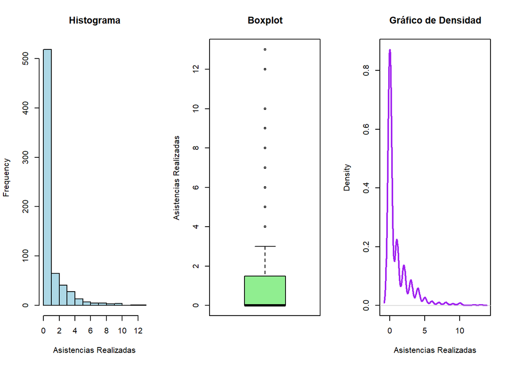

```r
par(mfrow = c(1, 3))  # Configurar para 3 gráficos en una fila
# Histograma
hist(datos$Ast,
     main = "Histograma",
     xlab = "Asistencias Realizadas",
     col = "lightblue",
     border = "black")
# Boxplot
boxplot(datos$Ast,
        main = "Boxplot",
        ylab = "Asistencias Realizadas",
        col = "lightgreen")
# Gráfico de Densidad
plot(density(datos$Ast),
     main = "Gráfico de Densidad",
     xlab = "Asistencias Realizadas",
     col = "purple",
     lwd = 2)
```

```r
par(mfrow = c(1, 1))  # Restaurar configuración
```

En el histograma, podemos observar que la mayoría de los jugadores han realizado pocas asistencias, con una cola larga hacia la derecha, lo que confirma la asimetría positiva observada en los estadísticos descriptivos. El boxplot muestra varios valores atípicos en el extremo superior, indicando que algunos jugadores han realizado un número excepcionalmente alto de asistencias. El gráfico de densidad refuerza la idea de que la distribución está sesgada hacia la derecha.

### 3.3. Análisis Descriptivo de Variables numéricas restantes.

#### 3.3.1 Cálculo de Estadísticos Descriptivos Resumidos.

Para las variables numéricas restantes, se realizará un análisis descriptivo resumido utilizando la función `skim()` del paquete `skimr`, que proporciona una visión general rápida de las estadísticas clave para cada variable numérica.

```r
variables_excluidas <- c("MP", "Gls", "Ast", "Age", "Min")

resumen_resto_numericas <- datos %>%
  select(where(is.numeric), -all_of(variables_excluidas)) %>%
  skim()

print(resumen_resto_numericas)
```

```
── Data Summary ────────────────────────
                           Values
Name                       Piped data
Number of rows             691
Number of columns          15
_______________________
Column type frequency:
  numeric                  15
________________________
Group variables            None

── Variable type: numeric ──────────────────────────────────────────────────────
   skim_variable n_missing complete_rate    mean     sd p0 p25  p50   p75  p100
 1 Starts                0             1 12.1    12.1    0   0 9    22    38
 2 G.PK                  0             1  1.38    2.70   0   0 0     2    23
 3 PK                    0             1  0.122   0.604  0   0 0     0     6
 4 PKatt                 0             1  0.149   0.704  0   0 0     0     7
 5 CrdY                  0             1  1.94    2.49   0   0 1     3    11
 6 CrdR                  0             1  0.0622  0.253  0   0 0     0     2
 7 Gls.1                 0             1  0.0873  0.175  0   0 0     0.11  2.03
 8 Ast.1                 0             1  0.0792  0.444  0   0 0     0.09 11.2
 9 G.A                   0             1  0.166   0.486  0   0 0.03  0.22 11.2
10 G.A.PK                0             1  0.161   0.483  0   0 0.03  0.21 11.2
11 xG                    0             1  1.52    2.76   0   0 0.3   1.8  21.8
12 npxG                  0             1  1.41    2.49   0   0 0.3   1.75 17.1
13 xA                    0             1  1.03    1.61   0   0 0.3   1.5  11.2
14 npxG.xA               0             1  2.44    3.82   0   0 0.9   3.4  27.4
15 xG.xA                 0             1  0.182   0.373  0   0 0.08  0.25  6.5
   hist
 1 ▇▂▂▂▂
 2 ▇▁▁▁▁
 3 ▇▁▁▁▁
 4 ▇▁▁▁▁
 5 ▇▂▁▁▁
 6 ▇▁▁▁▁
 7 ▇▁▁▁▁
 8 ▇▁▁▁▁
 9 ▇▁▁▁▁
10 ▇▁▁▁▁
11 ▇▁▁▁▁
12 ▇▁▁▁▁
13 ▇▁▁▁▁
14 ▇▁▁▁▁
15 ▇▁▁▁▁
```

El análisis descriptivo resumido de las variables numéricas restantes revela diversas características estadísticas. La mayoría de estas variables presentan una alta asimetría positiva, lo que indica que hay valores extremos que influyen en la media. Además, muchas de estas variables tienen una desviación típica considerablemente alta, lo que sugiere una gran variabilidad en los datos. Es importante tener en cuenta estos aspectos al interpretar los resultados y considerar posibles transformaciones o tratamientos adicionales si es necesario en etapas posteriores del análisis.

##### 3.3.2 Visualizaciones Resumidas.

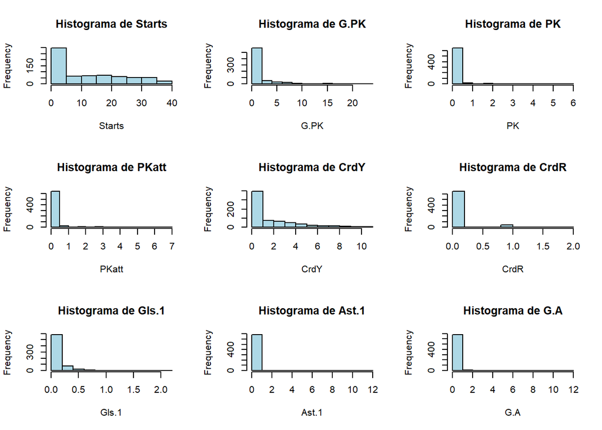

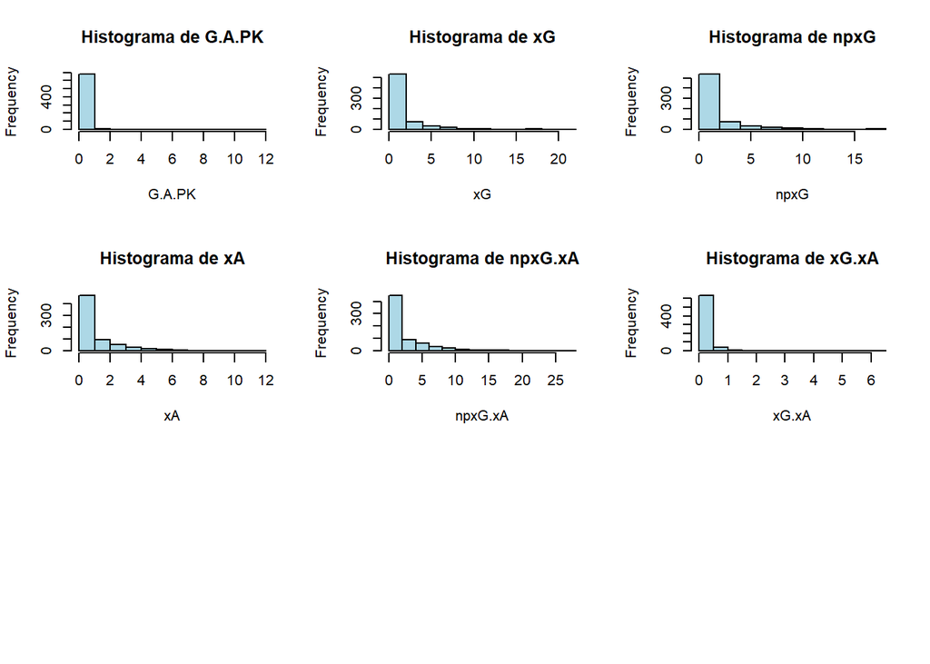

```r
par(mfrow = c(3, 3))  # Configurar para 9 gráficos en una cuadrícula 3x3
variables_numericas_resto <- datos %>%
  select(where(is.numeric), -all_of(variables_excluidas))
for (var in names(variables_numericas_resto)) {
  hist(variables_numericas_resto[[var]],
       main = paste("Histograma de", var),
       xlab = var,
       col = "lightblue",
       border = "black")
}
```

```r
par(mfrow = c(1, 1))  # Restaurar configuración
```

Estas visualizaciones proporcionan una visión general de la distribución de las variables numéricas restantes en el dataset. La mayoría de los histogramas muestran distribuciones asimétricas positivas, con colas largas hacia la derecha, lo que indica la presencia de valores extremos. Estos patrones son consistentes con los estadísticos descriptivos calculados anteriormente y sugieren que se deben considerar cuidadosamente estos aspectos en análisis posteriores.

### 3.4. Análisis Descriptivo de Variables Categóricas.

#### 3.4.1. Análisis de la variable Team (Equipo).

##### A. Frecuencias Absolutas y Relativas.

```r
frecuencias_team <- datos %>%
  group_by(Team) %>%
  summarise(
    Frecuencia_Absoluta = n(),
    Frecuencia_Relativa = n() / nrow(datos) * 100
  ) %>%
  arrange(desc(Frecuencia_Absoluta))
print(frecuencias_team)
```

```
# A tibble: 20 × 3
   Team                    Frecuencia_Absoluta Frecuencia_Relativa
   <fct>                                 <int>               <dbl>
 1 Arsenal                                  41                5.93
 2 Aston Villa                              41                5.93
 3 Everton                                  40                5.79
 4 Watford                                  39                5.64
 5 Brentford                                36                5.21
 6 Manchester United                        36                5.21
 7 Brighton & Hove Albion                   35                5.07
 8 Liverpool                                35                5.07
 9 Tottenham Hotspur                        35                5.07
10 Norwich City                             34                4.92
11 Wolverhampton Wanderers                  34                4.92
12 Leeds United                             33                4.78
13 Manchester City                          33                4.78
14 Newcastle United                         33                4.78
15 Burnley                                  32                4.63
16 Leicester City                           32                4.63
17 Chelsea                                  31                4.49
18 West Ham United                          31                4.49
19 Crystal Palace                           30                4.34
20 Southampton                              30                4.34
```

##### B. Visualizaciones.

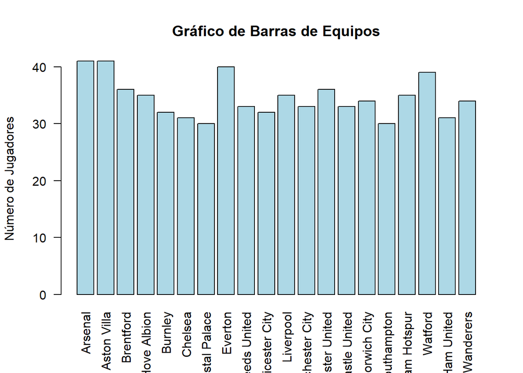

```r
# Gráfico de Barras
barplot(table(datos$Team),
        main = "Gráfico de Barras de Equipos",
        ylab = "Número de Jugadores",
        col = "lightblue",
        las = 2)
```

#### 3.4.2. Análisis de la variable Pos (Posición del jugador).

##### A. Frecuencias Absolutas y Relativas.

```r
frecuencias_pos <- datos %>%
  group_by(Pos) %>%
  summarise(
    Frecuencia_Absoluta = n(),
    Frecuencia_Relativa = n() / nrow(datos) * 100
  ) %>%
  arrange(desc(Frecuencia_Absoluta))
print(frecuencias_pos)
```

```
# A tibble: 4 × 3
  Pos   Frecuencia_Absoluta Frecuencia_Relativa
  <chr>               <int>               <dbl>
1 DF                    246                35.6
2 MF                    208                30.1
3 FW                    163                23.6
4 GK                     74                10.7
```

##### B. Visualizaciones.

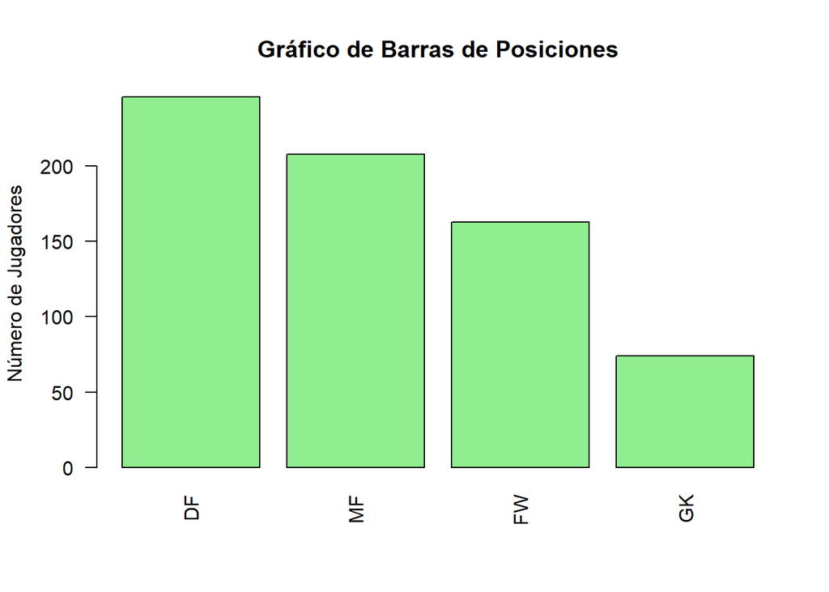

```r
# Gráfico de Barras ordenado de mayor a menor
pos_counts <- table(datos$Pos)
pos_counts <- pos_counts[order(-pos_counts)]
barplot(pos_counts,
        main = "Gráfico de Barras de Posiciones",
        ylab = "Número de Jugadores",
        col = "lightgreen",
        las = 2)
```

#### 3.4.3. Análisis de la variable Nation (Nacionalidad del jugador).

##### A. Frecuencias Absolutas y Relativas.

```r
frecuencias_nation <- datos %>%
  group_by(Nation) %>%
  summarise(
    Frecuencia_Absoluta = n(),
    Frecuencia_Relativa = n() / nrow(datos) * 100
  ) %>%
  arrange(desc(Frecuencia_Absoluta))
print(frecuencias_nation)
```

```
# A tibble: 67 × 3
   Nation Frecuencia_Absoluta Frecuencia_Relativa
   <fct>                <int>               <dbl>
 1 engENG                 277               40.1
 2 frFRA                   37                5.35
 3 esESP                   34                4.92
 4 brBRA                   29                4.20
 5 sctSCO                  27                3.91
 6 ieIRL                   24                3.47
 7 ptPOR                   22                3.18
 8 nlNED                   19                2.75
 9 wlsWAL                  17                2.46
10 dkDEN                   15                2.17
# ℹ 57 more rows
```

El análisis de la variable Nation (Nacionalidad del jugador) revela la diversidad de orígenes entre los jugadores de la Premier League. Algunos países tienen una representación significativamente mayor en el dataset, lo que podría reflejar factores como la popularidad del fútbol en esos países, las políticas de reclutamiento de los equipos, o la presencia de academias de formación. Esta información es crucial para entender cómo se distribuyen los jugadores según su nacionalidad y puede influir en análisis posteriores relacionados con el rendimiento individual y colectivo.

##### B. Visualizaciones.

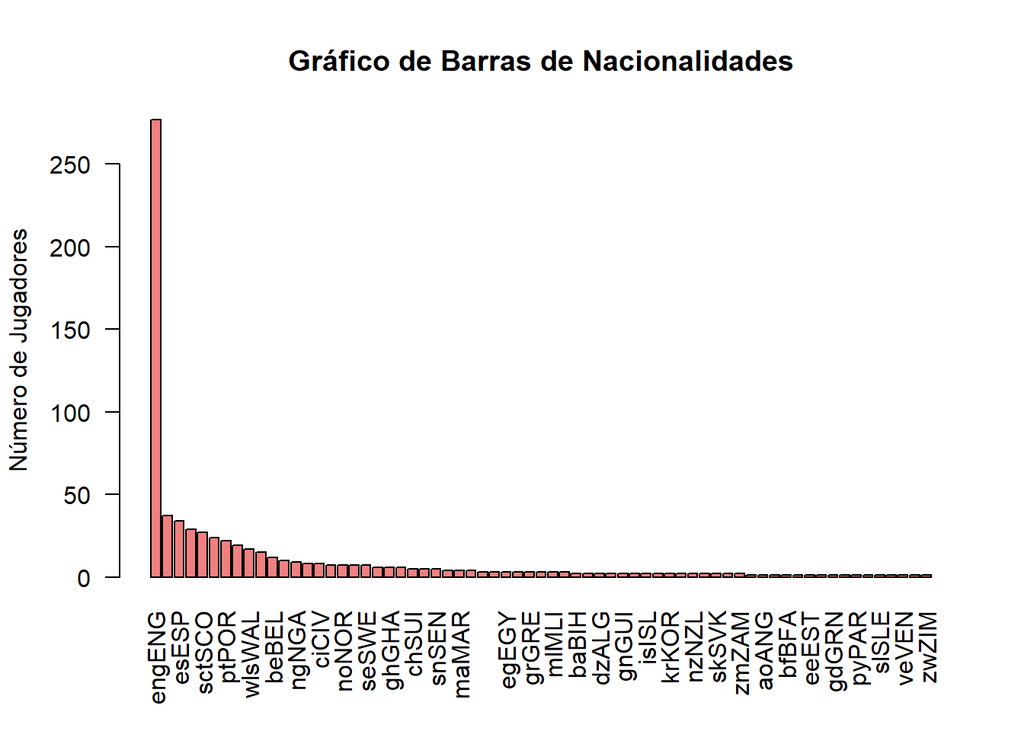

```r
# Gráfico de Barras ordenado de mayor a menor
nation_counts <- table(datos$Nation)
nation_counts <- nation_counts[order(-nation_counts)]
barplot(nation_counts,
        main = "Gráfico de Barras de Nacionalidades",
        ylab = "Número de Jugadores",
        col = "lightcoral",
        las = 2)
```

Hay claramente una dominancia de jugadores con la nacionalidad inglesa, seguida por jugadores de otras nacionalidades europeas. Esta distribución refleja la influencia del fútbol inglés en la Premier League y puede tener implicaciones en términos de estilo de juego, tácticas y rendimiento del equipo.

## 4. Análisis Bivariante.

El Análisis Bivariante se centra en explorar las relaciones entre pares de variables para identificar patrones y asociaciones.

### 4.1. Análisis de Correlación entre Variables Numéricas.

#### 4.1.1. Cálculo de la Matriz de Correlación.

```r
# Seleccionar solo las variables numéricas
variables_numericas <- datos %>%
  select(where(is.numeric))
# Calcular la matriz de correlación
matriz_correlacion <- cor(variables_numericas)
print(matriz_correlacion)
```

```
                Age         MP     Starts        Min        Gls       Ast
Age      1.00000000 0.38578375 0.37344273 0.37855879 0.16127589 0.1550555
MP       0.38578375 1.00000000 0.95196525 0.96089686 0.52957074 0.5515993
Starts   0.37344273 0.95196525 1.00000000 0.99761879 0.49480409 0.5084769
Min      0.37855879 0.96089686 0.99761879 1.00000000 0.49399712 0.5072018
Gls      0.16127589 0.52957074 0.49480409 0.49399712 1.00000000 0.6284025
Ast      0.15505547 0.55159928 0.50847691 0.50720184 0.62840250 1.0000000
G.PK     0.15411154 0.53375914 0.49559622 0.49402873 0.98274041 0.6225730
PK       0.10999840 0.23712184 0.23552859 0.23854352 0.56044154 0.3297242
PKatt    0.12087386 0.24103638 0.23723497 0.24024550 0.57013375 0.3357911
CrdY     0.25721605 0.68541669 0.71399883 0.71099839 0.35503437 0.3817835
CrdR     0.08195005 0.20812832 0.22467439 0.22073266 0.10013126 0.1437530
Gls.1    0.15483064 0.30425353 0.21019203 0.21765213 0.67704282 0.3728567
Ast.1   -0.00837191 0.04316159 0.02238888 0.02325487 0.07382218 0.1897317
G.A      0.04805397 0.14914181 0.09609516 0.09957590 0.31201593 0.3080103
G.A.PK   0.04082648 0.13972388 0.08761022 0.09090891 0.28876532 0.2956519
xG       0.16926400 0.55939615 0.50893541 0.50972570 0.93905638 0.6553066
npxG     0.16229747 0.57051203 0.51520429 0.51539291 0.92136637 0.6573766
xA       0.16048787 0.63413684 0.59459936 0.59374856 0.72226879 0.8534466
npxG.xA  0.17381647 0.63891778 0.58612558 0.58590540 0.90430297 0.7882865
xG.xA    0.04098255 0.15165578 0.07699276 0.08194854 0.32563187 0.2821333
              G.PK         PK      PKatt       CrdY         CrdR      Gls.1
Age     0.15411154 0.10999840 0.12087386 0.25721605  0.081950053 0.15483064
MP      0.53375914 0.23712184 0.24103638 0.68541669  0.208128324 0.30425353
Starts  0.49559622 0.23552859 0.23723497 0.71399883  0.224674393 0.21019203
Min     0.49402873 0.23854352 0.24024550 0.71099839  0.220732662 0.21765213
Gls     0.98274041 0.56044154 0.57013375 0.35503437  0.100131256 0.67704282
Ast     0.62257301 0.32972422 0.33579112 0.38178346  0.143753000 0.37285668
G.PK    1.00000000 0.39756097 0.41501431 0.35136034  0.096617712 0.67722599
PK      0.39756097 1.00000000 0.96993666 0.18799079  0.064110532 0.32630735
PKatt   0.41501431 0.96993666 1.00000000 0.18963285  0.069808260 0.34104384
CrdY    0.35136034 0.18799079 0.18963285 1.00000000  0.316082305 0.14097020
CrdR    0.09661771 0.06411053 0.06980826 0.31608231  1.000000000 0.04104421
Gls.1   0.67722599 0.32630735 0.34104384 0.14097020  0.041044206 1.00000000
Ast.1   0.07399228 0.03490722 0.03602406 0.01626491  0.015119809 0.05425712
G.A     0.31215655 0.15012746 0.15638643 0.06552669  0.028632624 0.41040987
G.A.PK  0.29727562 0.10142268 0.10800023 0.05858959  0.027217014 0.39546517
xG      0.91093712 0.57961375 0.59304121 0.36870678  0.088860099 0.61289498
npxG    0.92369896 0.43473454 0.44324196 0.37030882  0.085942798 0.60799010
xA      0.71059762 0.40123072 0.41282414 0.42986634  0.080943950 0.41209137
```

[output cut: 29 more lines]

```
Ast     0.78828649  0.282133269
G.PK    0.90093798  0.320042555
PK      0.45199784  0.182359039
PKatt   0.46266389  0.193345594
CrdY    0.42241636  0.053273566
CrdR    0.08950391 -0.002546255
Gls.1   0.56977650  0.376687042
Ast.1   0.10832520  0.704676805
G.A     0.30472687  0.779557925
G.A.PK  0.28728881  0.774481024
xG      0.94926973  0.356336031
npxG    0.95666765  0.354702666
xA      0.89389677  0.304880240
npxG.xA 1.00000000  0.359475819
xG.xA   0.35947582  1.000000000
```

#### 4.1.2. Visualización de la Matriz de Correlación.

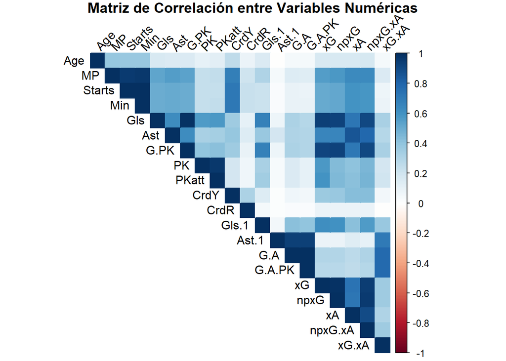

```r
# Visualización de la matriz de correlación
corrplot(matriz_correlacion, method = "color", type = "upper",
         tl.col = "black", tl.srt = 45,
         title = "Matriz de Correlación entre Variables Numéricas",
         mar = c(0,0,1,0))
```

No se puede observar ninguna correlación negativa significativa entre las variables numéricas, lo que indica que no hay relaciones inversas fuertes en este conjunto de datos.

#### 4.1.3. Análisis de Parejas de Variables Numéricas. (Diagramas de Dispersión).

##### A. Diagramas de Dispersión entre Minutos Jugados y Goles Anotados.

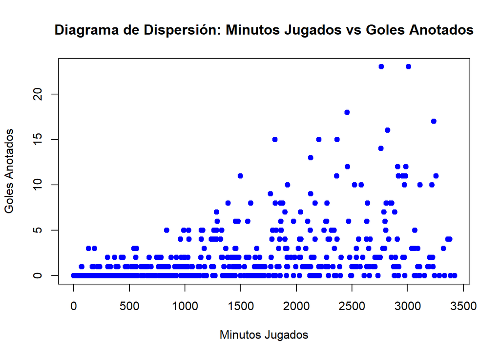

```r
plot(datos$Min, datos$Gls,
     main = "Diagrama de Dispersión: Minutos Jugados vs Goles Anotados",
     xlab = "Minutos Jugados",
     ylab = "Goles Anotados",
     col = "blue",
     pch = 19)
```

```r
pearson_3 <- cor(datos$Min, datos$Gls, method = "pearson")
print(pearson_3)
```

```
[1] 0.4939971
```

El diagrama de dispersión entre Minutos Jugados y Goles Anotados muestra una tendencia positiva clara, indicando que a medida que los jugadores juegan más minutos, tienden a anotar más goles. Esta relación sugiere que el tiempo de juego es un factor importante para el rendimiento ofensivo de los jugadores. Por otro lado, el coeficiente de pearson nos confirma lo visto en el scatter plot que los jugadores cuantos mas minutos jugan tienden a meter más goles, pero el coeficiente no es del todo alto, lo que indica que otras variables como la posición pueden influir también.

##### B. Diagramas de Dispersión entre Minutos Jugados y Edad del Jugador.

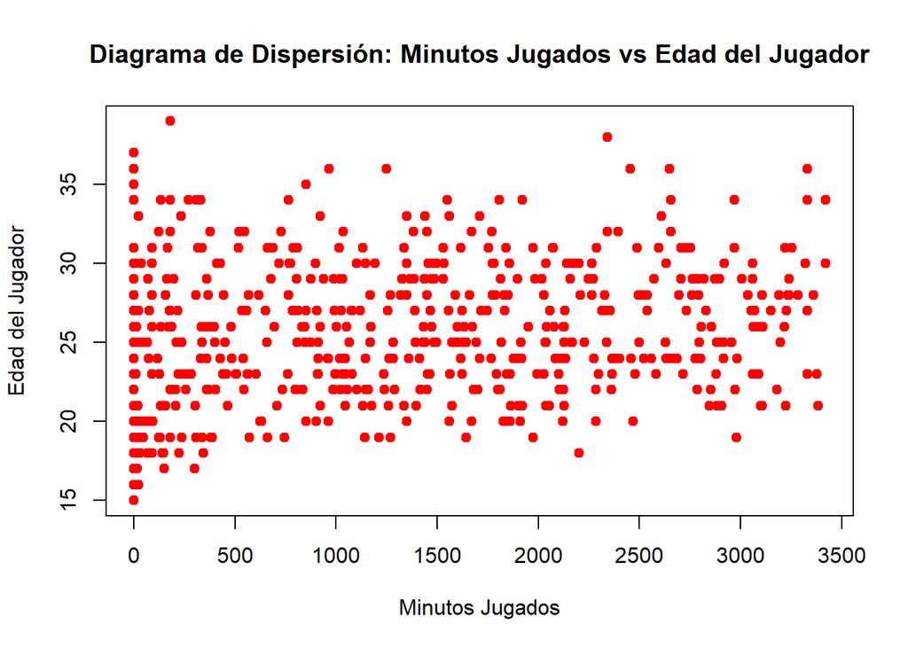

```r
plot(datos$Min, datos$Age,
     main = "Diagrama de Dispersión: Minutos Jugados vs Edad del Jugador",
     xlab = "Minutos Jugados",
     ylab = "Edad del Jugador",
     col = "red",
     pch = 19)
```

```r
pearson_2 <- cor(datos$Min, datos$Age, method = "pearson")
print(pearson_2)
```

```
[1] 0.3785588
```

##### C. Diagramas de Dispersión entre Goles Anotados y Goles Esperados.

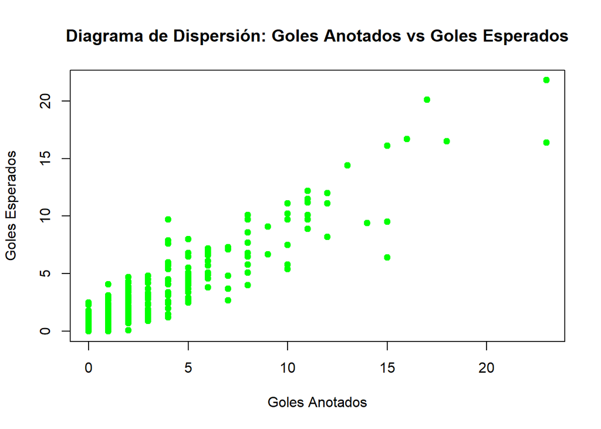

```r
plot(datos$Gls, datos$xG,
     main = "Diagrama de Dispersión: Goles Anotados vs Goles Esperados",
     xlab = "Goles Anotados",
     ylab = "Goles Esperados",
     col = "green",
     pch = 19)
```

El diagrama de dispersión entre Goles Anotados y Goles Esperados muestra una relación positiva, indicando que los jugadores que anotan más goles tienden a tener mayores valores de goles esperados. Esta relación sugiere que los jugadores que están en mejores posiciones para anotar (reflejadas por los goles esperados) efectivamente convierten esas oportunidades en goles reales. Por lo tanto, la variable de goles esperados es un buen predictor del rendimiento ofensivo de los jugadores.

```r
pearson_1 <- cor(datos$Gls, datos$xG, method = 'pearson')
print(pearson_1)
```

```
[1] 0.9390564
```

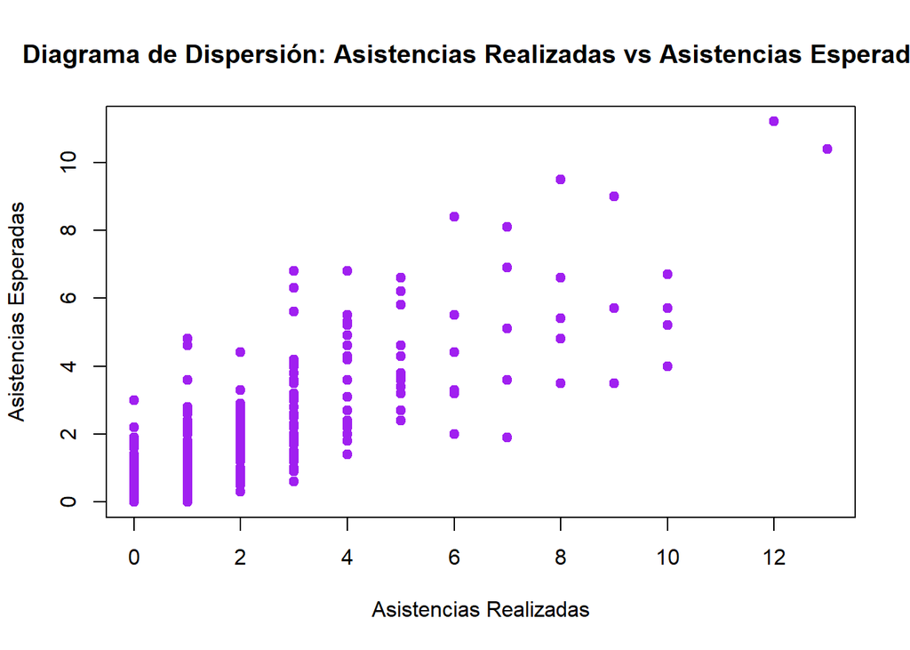

```r
plot(datos$Ast, datos$xA,
     main = "Diagrama de Dispersión: Asistencias Realizadas vs Asistencias Esperadas",
     xlab = "Asistencias Realizadas",
     ylab = "Asistencias Esperadas",
     col = "purple",
     pch = 19)
```

```r
pearson_4 <- cor(datos$Ast, datos$xA, method = "pearson")
print(pearson_4)
```

```
[1] 0.8534466
```

El diagrama de dispersión entre Asistencias Realizadas y Asistencias Esperadas muestra una relación positiva, indicando que los jugadores que realizan más asistencias tienden a tener mayores valores de asistencias esperadas. Esta relación sugiere que los jugadores que están en mejores posiciones para asistir (reflejadas por las asistencias esperadas) efectivamente convierten esas oportunidades en asistencias reales. Por lo tanto, la variable de asistencias esperadas es un buen predictor del rendimiento ofensivo de los jugadores.

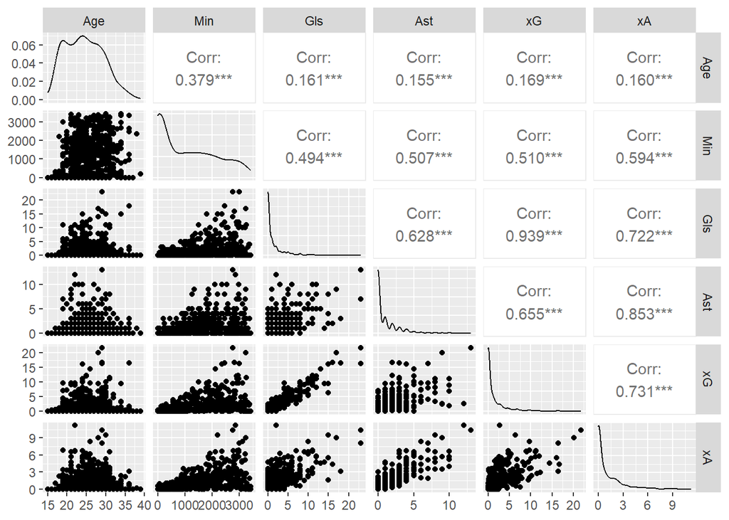

```r
ggpairs(datos %>% select(Age, Min, Gls, Ast, xG, xA))
```

El gráfico de pares confirma los patrones observados anteriormente: existe una fuerte relación entre los goles y sus métricas esperadas (Gls–xG) y entre las asistencias y las asistencias esperadas (Ast–xA). Además, se mantiene una correlación moderada entre los minutos jugados y el rendimiento ofensivo, mientras que la edad muestra una influencia limitada sobre el desempeño de los jugadores.

### 4.2. Análisis Bivariante entre Variables Categóricas y Numéricas.

#### 4.2.1 Análisis de la variable edad con respecto a los goles y asistencias.

Queremos ver si la edad del jugador influye en su rendimiento ofensivo, medido por goles y asistencias.

##### A. Boxplots de Edad vs Goles Anotados.

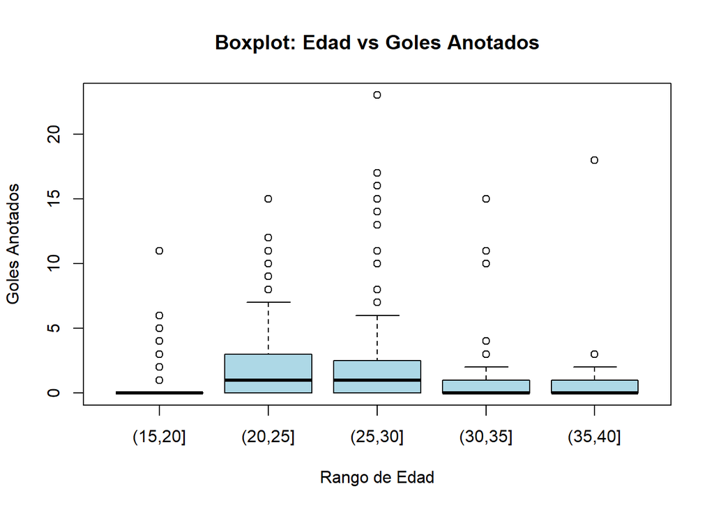

```r
boxplot(Gls ~ cut(Age, breaks = c(15, 20, 25, 30, 35, 40)),
        data = datos,
        main = "Boxplot: Edad vs Goles Anotados",
        xlab = "Rango de Edad",
        ylab = "Goles Anotados",
        col = "lightblue")
```

También observamos que hay un jugador entre los 35 y los 40 años que ha anotado una cantidad significativa de goles, lo que indica que algunos jugadores pueden mantener un alto nivel de rendimiento incluso en edades avanzadas.

Ese jugador es:

```r
datos %>%
  filter(Age >= 35 & Age <= 40 & Gls == max(Gls[Age >= 35 & Age <= 40])) %>%
  select(Player, Age, Gls, Team)
```

```
             Player Age Gls              Team
1 Cristiano Ronaldo  36  18 Manchester United
```

##### B. Boxplots de Edad vs Asistencias Realizadas.

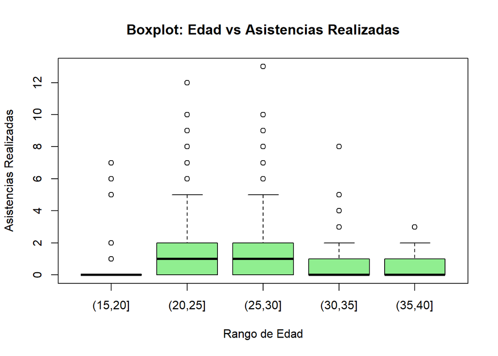

```r
boxplot(Ast ~ cut(Age, breaks = c(15, 20, 25, 30, 35, 40)),
        data = datos,
        main = "Boxplot: Edad vs Asistencias Realizadas",
        xlab = "Rango de Edad",
        ylab = "Asistencias Realizadas",
        col = "lightgreen")
```

El jugador que más destaca es:

```r
datos %>%
  filter(Age >= 25 & Age < 30 & Ast == max(Ast[Age >= 25 & Age < 30])) %>%
  select(Player, Age, Ast, Team)
```

```
         Player Age Ast      Team
1 Mohamed Salah  29  13 Liverpool
```

#### 4.2.2 Análisis de la variable Posición con respecto a los goles y asistencias.

Queremos ver si la posición del jugador influye en su rendimiento ofensivo, medido por goles y asistencias.

##### A. Boxplots de Posición vs Goles Anotados.

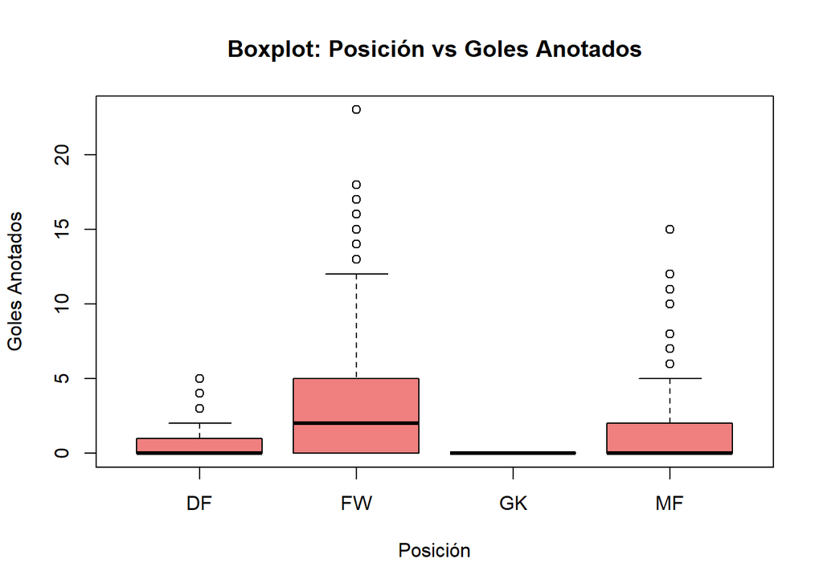

```r
boxplot(Gls ~ Pos,
        data = datos,
        main = "Boxplot: Posición vs Goles Anotados",
        xlab = "Posición",
        ylab = "Goles Anotados",
        col = "lightcoral")
```

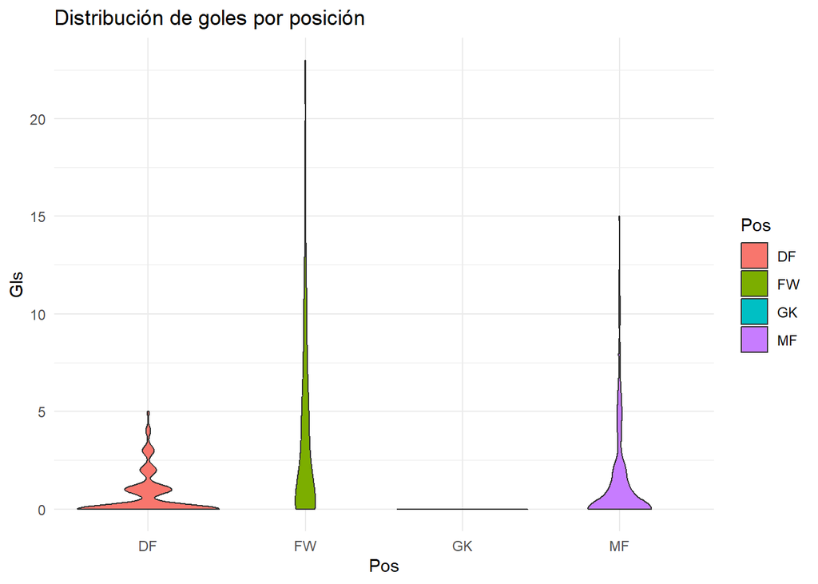

```r
ggplot(datos, aes(x = Pos, y = Gls, fill = Pos)) +
  geom_violin() +
  theme_minimal() +
  labs(title = "Distribución de goles por posición")
```

Tanto el boxplot como el gráfico de violín de Posición vs Goles Anotados confirman que los delanteros (FW) son el grupo con mayor número de goles, lo que coincide con su función principal dentro del equipo. Además, el gráfico de violín permite observar la distribución interna de los goles dentro de cada posición: los delanteros muestran una mayor variabilidad y una cola larga hacia valores altos, mientras que defensas (DF) y mediocampistas (MF) concentran la mayoría de sus registros en valores bajos. Los porteros (GK), como era de esperar, apenas registran goles.

##### B. Boxplots de Posición vs Asistencias Realizadas.

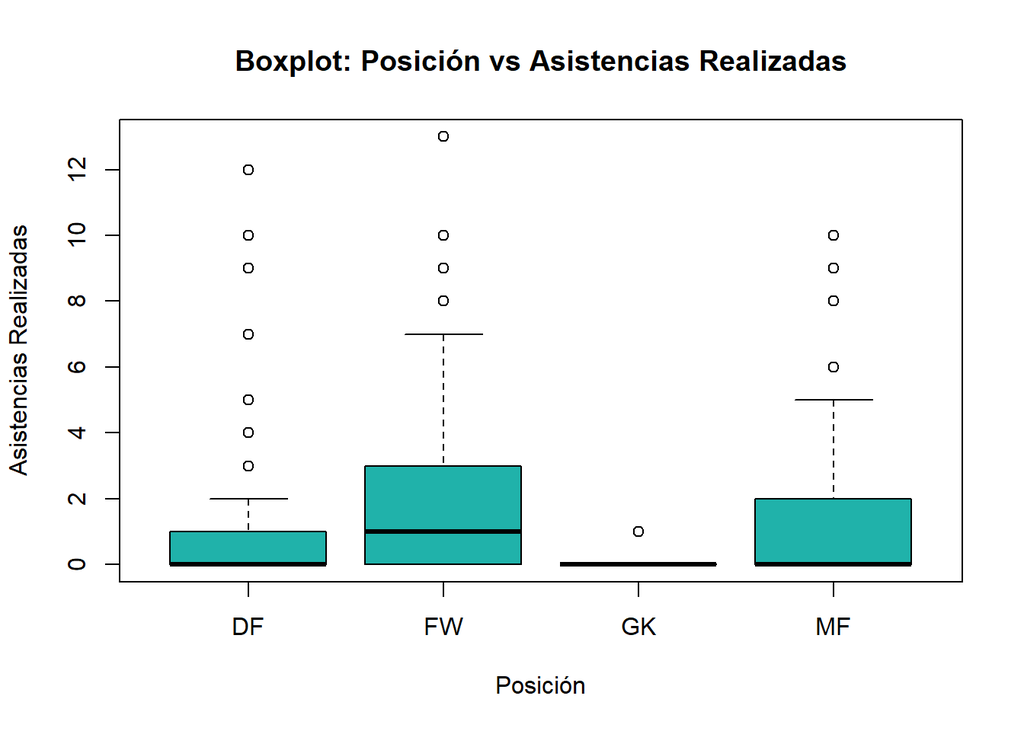

```r
boxplot(Ast ~ Pos,
        data = datos,
        main = "Boxplot: Posición vs Asistencias Realizadas",
        xlab = "Posición",
        ylab = "Asistencias Realizadas",
        col = "lightseagreen")
```

El boxplot de Posición vs Asistencias Realizadas muestra que los delanteros (FF) tienden a realizar más asistencias en comparación con otras posiciones. Esto no es consistente con el rol de los delanteros, que generalmente se centran más en anotar goles que en asistir. Sin embargo, algunos delanteros pueden tener habilidades de pase excepcionales y contribuir significativamente a las asistencias del equipo. También habla de un estilo de juego más colaborativo donde los delanteros participan activamente en la creación de oportunidades de gol para sus compañeros de equipo.

#### 4.2.3 Análisis de la variable Equipo con respecto a los minutos jugados y la rotación de jugadores.

Queremos ver si equipos que compiten a nivel internacional tienen una mayor rotación de jugadores en comparación a equipos que jueguen a nivel nacional. Debido a que tienen más o menos carga de partidos. Los equipos con más partidos deberán seguir una mayor rotación de jugadores que equipos más pequeños.

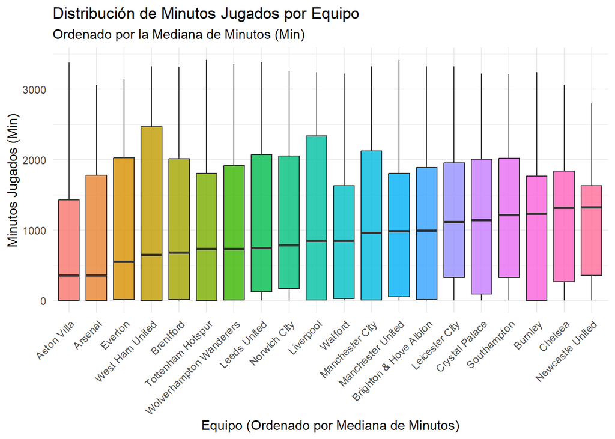

```r
#| label: boxplot_minutos_por_equipo
#| echo: true
#| fig-width: 12
#| fig-height: 8

# 1. Preparar y ordenar los datos
# Usamos 'datos' y las columnas 'Min' y 'Team'
df_minutos_club <- datos %>%
  # Limpiar missings si existen
  filter(!is.na(Min), !is.na(Team)) %>%

  # 2. Ordenar el factor 'Team' por la mediana de 'Min'
  # fct_reorder es útil para que los clubes aparezcan en orden lógico en el eje X
  mutate(Team = fct_reorder(Team, Min, .fun = median))

# 3. Generar el Boxplot
p_minutos_club <- df_minutos_club %>%
  ggplot(aes(x = Team, y = Min, fill = Team)) +
  geom_boxplot(alpha = 0.8, outlier.color = "red") +
  labs(title = "Distribución de Minutos Jugados por Equipo",
       subtitle = "Ordenado por la Mediana de Minutos (Min)",
       x = "Equipo (Ordenado por Mediana de Minutos)",
       y = "Minutos Jugados (Min)") +
  theme_minimal() +
  # Rotar etiquetas del eje X para evitar solapamiento (necesario si hay muchos clubes)
  theme(axis.text.x = element_text(angle = 45, hjust = 1),
        legend.position = "none") # Eliminar leyenda

print(p_minutos_club)
```

Estos patrones reflejan las diferentes estrategias de gestión de plantillas adoptadas por los clubes, posiblemente influenciadas por su participación en competiciones internacionales y la carga de partidos asociada.

### Análisis Bivariante de Variables Categóricas.

#### 4.3.1 Análisis de la variable Posición con respecto al Equipo.

##### A. Tabla de Contingencia de Posición vs Equipo.

```r
tabla_pos_equipo <- table(datos$Pos, datos$Team)
print(tabla_pos_equipo)
```

```
     Arsenal Aston Villa Brentford Brighton & Hove Albion Burnley Chelsea
  DF      17          13        14                     12      12      12
  FW      10           9         6                      8       7       6
  GK       4           5         5                      4       4       3
  MF      10          14        11                     11       9      10

     Crystal Palace Everton Leeds United Leicester City Liverpool
  DF             10      12           11             13        13
  FW              8       9            6              7         9
  GK              3       4            2              3         4
  MF              9      15           14              9         9

     Manchester City Manchester United Newcastle United Norwich City
  DF              11                11               12           12
  FW              10                13                6           11
  GK               4                 3                4            4
  MF               8                 9               11            7

     Southampton Tottenham Hotspur Watford West Ham United
  DF          10                12      12              12
  FW           4                 6      13               7
  GK           4                 3       4               3
  MF          12                14      10               9

     Wolverhampton Wanderers
  DF                      15
  FW                       8
  GK                       4
  MF                       7
```

##### B. Visualización de la Distribución de Posiciones por Equipo.

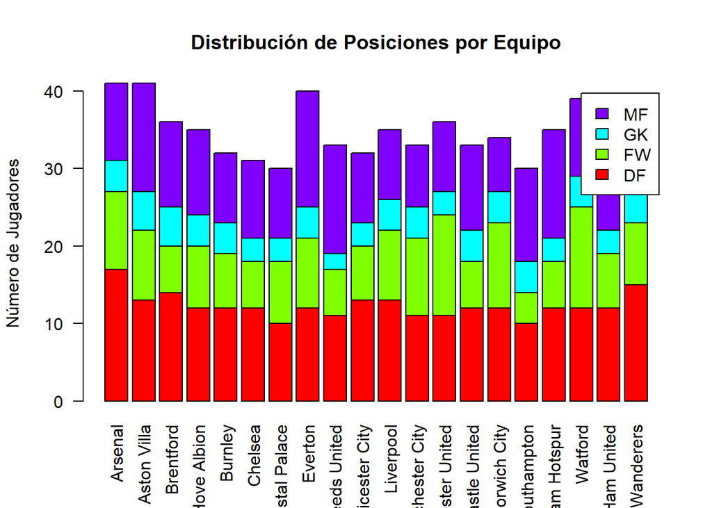

```r
# Gráfico de barras apiladas

barplot(tabla_pos_equipo,
        main = "Distribución de Posiciones por Equipo",
        ylab = "Número de Jugadores",
        col = rainbow(nrow(tabla_pos_equipo)),
        legend = rownames(tabla_pos_equipo),
        las = 2)
```

El gráfico de barras apiladas revela la **asociación entre el equipo y la composición de su plantilla**. Al observar las proporciones de los colores (grupos de posición) para cada equipo, se identifica si algún club se desvía del promedio de la liga. Por ejemplo, si un equipo muestra una proporción notablemente mayor de jugadores en la categoría **Ataque** que el resto, indica un posible **sesgo en el *scouting*** o un **énfasis táctico** en esa área del campo. Este análisis fundamenta una pregunta sobre si esta composición de plantilla es **independiente** del club.

## 4. Identificación de Patrones y Formulación de Preguntas.

El EDA ha permitido la transición de la descripción a la síntesis, revelando patrones fundamentales que requieren validación formal mediante Inferencia Estadística.

### 4.1 Identificación y Descripción de los Patrones principales.

Los patrones se basan en la evidencia observada en los análisis univariante y bivariante, y se presentan con rigor académico:

#### 1. Concentración Extrema del Rendimiento Ofensivo (Asimetría y Outliners)

- El análisis univariante (Sección 3.2.4) de Goles (Gls) y Asistencias (Ast) reveló una asimetría positiva elevada (Asimetría > 4.0), confirmada por los Boxplots que muestran numerosos outliers. Este patrón indica que la producción ofensiva de élite está altamente concentrada en un pequeño subconjunto de jugadores.

### 4.2 Formulación de Preguntas para Inferencia Futura.

Las siguientes preguntas están formuladas como hipótesis estadísticas que requieren métodos de inferencia para su validación formal.

[output not shown]

## 5. Conclusiones del Análisis Exploratorio de Datos (EDA).

El Análisis Exploratorio de Datos ha cumplido su objetivo de describir la estructura, asegurar la calidad de los datos y generar hipótesis válidas, proporcionando una base sólida para la Inferencia Estadística.

### 5.2 Implicaciones para Análisis Futuros.

Este análisis es puramente descriptivo; las relaciones identificadas no implican causalidad. La principal limitación es la ausencia de variables cruciales como el Salario o la Clasificación Final del Equipo, que son necesarias para medir el impacto financiero y deportivo del rendimiento. Estas limitaciones deben abordarse en estudios futuros para obtener una comprensión más completa del rendimiento en la Premier League.